# **Business Problem Understanding**

# we need to predict the vechile insurence **claim** is fradulent or not based on the data which given the data contains detailed about

1. Demographics Data
2. Policy Information
3. Data of Claim
4. Data of Vehicle

Claim related fraud is a huge problem in the insurance industry.It is complex and difficult to identify those unwanted claims. With Random Forest Machine Learning Algorithm, I am trying to solve and help the General Insurance industry with this problem.

```python
#importing basic libraries
import pandas as pd
import numpy as np
import matplotlib.pyplot as plt
import seaborn as sns
pd.set_option('display.max_columns', None)
pd.set_option('display.max_rows', 50)
```

```python
from google.colab import drive
drive.mount("/content/drive")
```

# **EDA**

```python
#Reading files using pandas
df1=pd.read_csv("/content/drive/MyDrive/TrainData/Train_Claim.csv")
df2=pd.read_csv("/content/drive/MyDrive/TrainData/Train_Demographics.csv")
df3=pd.read_csv("/content/drive/MyDrive/TrainData/Train_Policy.csv")
df4=pd.read_csv("/content/drive/MyDrive/TrainData/Train_Vehicle_new.csv")
df5=pd.read_csv("/content/drive/MyDrive/TrainData/Traindata_with_Target.csv")
```

```python
#checking shape of each datasets
print("df1:",df1.shape)
print("df2:",df2.shape)
print("df3:",df3.shape)
print("df4:",df4.shape)
print("df5:",df5.shape)
```

```
df1: (28836, 19)
df2: (28836, 10)
df3: (28836, 10)
df4: (28836, 5)
df5: (28836, 2)
```

```python
#merging all datasets based on "CstomerID"
sample_1=pd.merge(df1,df2)
sample_2=pd.merge(sample_1,df3)
sample_3=pd.merge(sample_2,df4)
master=pd.merge(sample_3,df5)
```

```python
master.head()
```

|  | CustomerID | DateOfIncident | TypeOfIncident | TypeOfCollission | SeverityOfIncident | AuthoritiesContacted | IncidentState | IncidentCity | IncidentAddress | IncidentTime | NumberOfVehicles | PropertyDamage | BodilyInjuries | Witnesses | PoliceReport | AmountOfTotalClaim | AmountOfInjuryClaim | AmountOfPropertyClaim | AmountOfVehicleDamage | InsuredAge | InsuredZipCode | InsuredGender | InsuredEducationLevel | InsuredOccupation | InsuredHobbies | CapitalGains | CapitalLoss | Country | InsurancePolicyNumber | … |
| --- | --- | --- | --- | --- | --- | --- | --- | --- | --- | --- | --- | --- | --- | --- | --- | --- | --- | --- | --- | --- | --- | --- | --- | --- | --- | --- | --- | --- | --- | --- |
| 0 | Cust10000 | 2015-02-03 | Multi-vehicle Collision | Side Collision | Total Loss | Police | State7 | City1 | Location 1311 | 17 | 3 | ? | 1 | 0 | ? | 65501 | 13417 | 6071 | 46013 | 35 | 454776 | MALE | JD | armed-forces | movies | 56700 | -48500 | India | 119121 | … |
| 1 | Cust10001 | 2015-02-02 | Multi-vehicle Collision | Side Collision | Total Loss | Police | State7 | City5 | Location 1311 | 10 | 3 | YES | 2 | 1 | YES | 61382 | 15560 | 5919 | 39903 | 36 | 454776 | MALE | JD | tech-support | cross-fit | 70600 | -48500 | India | 119122 | … |
| 2 | Cust10002 | 2015-01-15 | Single Vehicle Collision | Side Collision | Minor Damage | Other | State8 | City6 | Location 2081 | 22 | 1 | YES | 2 | 3 | NO | 66755 | 11630 | 11630 | 43495 | 33 | 603260 | MALE | JD | armed-forces | polo | 66400 | -63700 | India | 119123 | … |
| 3 | Cust10003 | 2015-01-19 | Single Vehicle Collision | Side Collision | Minor Damage | Other | State9 | City6 | Location 2081 | 22 | 1 | YES | 2 | 3 | NO | 66243 | 12003 | 12003 | 42237 | 36 | 474848 | MALE | JD | armed-forces | polo | 47900 | -73400 | India | 119124 | … |
| 4 | Cust10004 | 2015-01-09 | Single Vehicle Collision | Rear Collision | Minor Damage | Fire | State8 | City6 | Location 1695 | 10 | 1 | NO | 2 | 1 | YES | 53544 | 8829 | 7234 | 37481 | 29 | 457942 | FEMALE | High School | exec-managerial | dancing | 0 | -41500 | India | 119125 | … |

```python
# Making a list of missing value types
missing_values = ["MISSEDDATA","NA","?","MISSINGVALUE","???",-5,"MISSINGVAL",-1,"N/A","na"]
```

```python
#we create one missing values list by using that if that comes in any place we replace it with nan
for column in master.columns:
    for missing in missing_values:
        master[column] = np.where(master[column]==missing, np.NaN, master[column])
```

```python
master.isnull().sum()
```

```
CustomerID                        0
DateOfIncident                    0
TypeOfIncident                    0
TypeOfCollission               5162
SeverityOfIncident                0
AuthoritiesContacted              0
IncidentState                     0
IncidentCity                      0
IncidentAddress                   0
IncidentTime                     31
NumberOfVehicles                  0
PropertyDamage                10459
BodilyInjuries                    0
Witnesses                        46
PoliceReport                   9805
AmountOfTotalClaim               50
AmountOfInjuryClaim               0
AmountOfPropertyClaim             0
AmountOfVehicleDamage             0
InsuredAge                        0
InsuredZipCode                    0
InsuredGender                    30
InsuredEducationLevel             0
InsuredOccupation                 0
InsuredHobbies                    0
CapitalGains                      0
CapitalLoss                       0
Country                           2
InsurancePolicyNumber             0
CustomerLoyaltyPeriod             0
DateOfPolicyCoverage              0
InsurancePolicyState              0
Policy_CombinedSingleLimit        0
Policy_Deductible                 0
PolicyAnnualPremium             141
UmbrellaLimit                     0
InsuredRelationship               0
VehicleID                         0
VehicleMake                      50
VehicleModel                      0
VehicleYOM                        0
ReportedFraud                     0
dtype: int64
```

```python
master.info()
```

```
<class 'pandas.core.frame.DataFrame'>
Int64Index: 28836 entries, 0 to 28835
Data columns (total 42 columns):
 #   Column                      Non-Null Count  Dtype
---  ------                      --------------  -----
 0   CustomerID                  28836 non-null  object
 1   DateOfIncident              28836 non-null  object
 2   TypeOfIncident              28836 non-null  object
 3   TypeOfCollission            23674 non-null  object
 4   SeverityOfIncident          28836 non-null  object
 5   AuthoritiesContacted        28836 non-null  object
 6   IncidentState               28836 non-null  object
 7   IncidentCity                28836 non-null  object
 8   IncidentAddress             28836 non-null  object
 9   IncidentTime                28805 non-null  float64
```

[output cut: 34 more lines]

```python
#checking missing values percent using isnull function
master.isnull().sum()/len(master)*100
```

```
CustomerID                     0.000000
DateOfIncident                 0.000000
TypeOfIncident                 0.000000
TypeOfCollission              17.901235
SeverityOfIncident             0.000000
AuthoritiesContacted           0.000000
IncidentState                  0.000000
IncidentCity                   0.000000
IncidentAddress                0.000000
IncidentTime                   0.107505
NumberOfVehicles               0.000000
PropertyDamage                36.270634
BodilyInjuries                 0.000000
Witnesses                      0.159523
PoliceReport                  34.002636
AmountOfTotalClaim             0.173394
AmountOfInjuryClaim            0.000000
AmountOfPropertyClaim          0.000000
AmountOfVehicleDamage          0.000000
InsuredAge                     0.000000
InsuredZipCode                 0.000000
InsuredGender                  0.104037
InsuredEducationLevel          0.000000
InsuredOccupation              0.000000
InsuredHobbies                 0.000000
CapitalGains                   0.000000
CapitalLoss                    0.000000
Country                        0.006936
InsurancePolicyNumber          0.000000
CustomerLoyaltyPeriod          0.000000
DateOfPolicyCoverage           0.000000
InsurancePolicyState           0.000000
Policy_CombinedSingleLimit     0.000000
Policy_Deductible              0.000000
PolicyAnnualPremium            0.488972
UmbrellaLimit                  0.000000
InsuredRelationship            0.000000
VehicleID                      0.000000
VehicleMake                    0.173394
VehicleModel                   0.000000
VehicleYOM                     0.000000
ReportedFraud                  0.000000
dtype: float64
```

# Imputing Missing Values for both **numeric** and **catagorical**

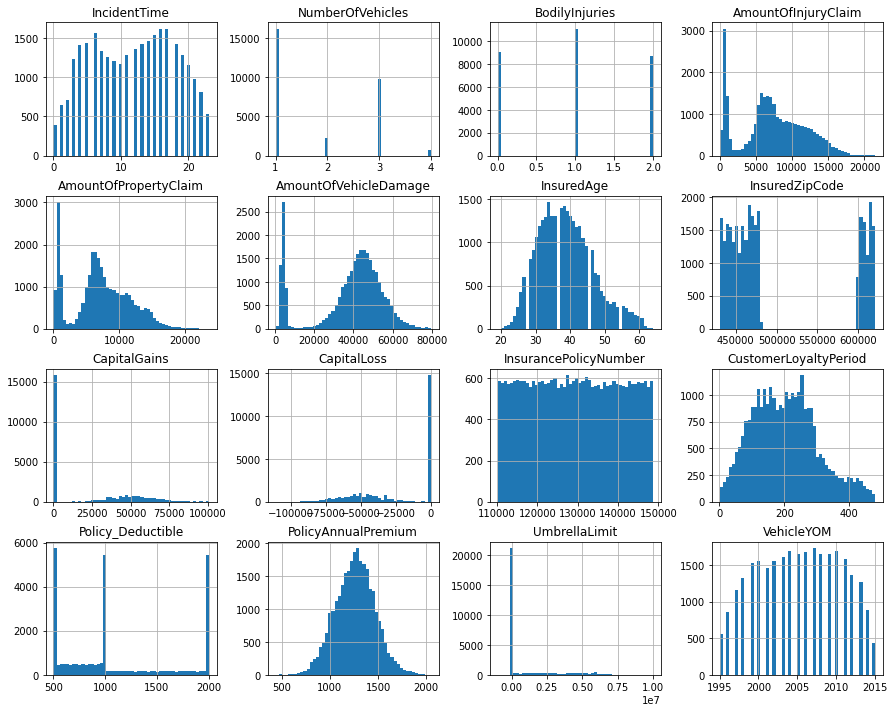

```python
#by using hist graph we can see how data distributed
master.hist(bins=50,figsize=(15, 12))
plt.show()
```

```python
##  Replace NAN values with most occured category in TypeOfCollission
Mode_Category = master["TypeOfCollission"].mode()[0]
master["TypeOfCollission"].fillna(Mode_Category,inplace=True)
```

```python
##  Replace NAN values with median in IncidentTime
median=master['IncidentTime'].median()
master['IncidentTime'].fillna(median,inplace=True)
```

```python
#drop country missing value data
master.drop(['Country'],axis=1,inplace=True)
```

```python
##  Replace NAN values with median  in witness
median_1=master['Witnesses'].median()
master['Witnesses'].fillna(median_1,inplace=True)
```

```python
##  Replace NAN values with most occured category in police report
#Mode_Category_1 = master["PoliceReport"].mode()[0]
#master["PoliceReport"].fillna(Mode_Category_1,inplace=True)
```

```python
master['PoliceReport'].fillna('missing',inplace=True)
```

```python
master['PoliceReport']
```

```
0        missing
1            YES
2             NO
3             NO
4            YES
          ...
28831    missing
28832        YES
28833        YES
28834        YES
28835        YES
Name: PoliceReport, Length: 28836, dtype: object
```

```python
###  Replace NAN values with median in AmountOfTotalClaim
median_2=master['AmountOfTotalClaim'].median()
master['AmountOfTotalClaim'].fillna(median_2,inplace=True)
```

```python
##  Replace NAN values with most occured category in gender
Mode_Category_2 = master["InsuredGender"].mode()[0]
master["InsuredGender"].fillna(Mode_Category_2,inplace=True)
```

```python
master.drop(['CustomerID','VehicleID','InsurancePolicyNumber'],axis=1,inplace=True)
```

```python
###  Replace NAN values with median in PolicyAnnualPremium
median_3=master['PolicyAnnualPremium'].median()
master['PolicyAnnualPremium'].fillna(median_3,inplace=True)
```

```python
##  Replace NAN values with most occured category in VehicleMake
Mode_Category_3 = master["VehicleMake"].mode()[0]
master["VehicleMake"].fillna(Mode_Category_3,inplace=True)
```

```python
master.isnull().sum().any()
```

[output not shown]

```python
master['PropertyDamage'].fillna('missing',inplace=True)
```

```python
master['PropertyDamage']
```

```
0        missing
1            YES
2            YES
3            YES
4             NO
          ...
28831         NO
28832        YES
28833        YES
28834    missing
28835         NO
Name: PropertyDamage, Length: 28836, dtype: object
```

```python
#master['PD']=[1 if i=='missing' else 0 for i in master.PropertyDamage ]
#master=master.drop(columns=['PropertyDamage'])
```

```python
master.info()
```

```
<class 'pandas.core.frame.DataFrame'>
Int64Index: 28836 entries, 0 to 28835
Data columns (total 38 columns):
 #   Column                      Non-Null Count  Dtype
---  ------                      --------------  -----
 0   DateOfIncident              28836 non-null  object
 1   TypeOfIncident              28836 non-null  object
 2   TypeOfCollission            28836 non-null  object
 3   SeverityOfIncident          28836 non-null  object
 4   AuthoritiesContacted        28836 non-null  object
 5   IncidentState               28836 non-null  object
 6   IncidentCity                28836 non-null  object
 7   IncidentAddress             28836 non-null  object
 8   IncidentTime                28836 non-null  float64
 9   NumberOfVehicles            28836 non-null  float64
```

[output cut: 30 more lines]

```python
#two numerical feature shows object type change type to numerical
master['AmountOfTotalClaim'] = master['AmountOfTotalClaim'].astype('int')
master['Witnesses']=master['Witnesses'].astype('int')
```

```python
master['ReportedFraud'].value_counts()
```

```
N    21051
Y     7785
Name: ReportedFraud, dtype: int64
```

# Visuvalization

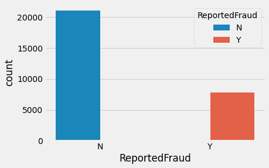

```python
plt.style.use('fivethirtyeight')
ax = sns.countplot(x='ReportedFraud', data=master, hue='ReportedFraud')
```

```python
#function for crosstabs
def cross_tab(x,y):
    crtab = pd.crosstab(master[x], master[y])
    return crtab
```

```python
#insuredgender vs ReportedFraud
cross_tab('InsuredGender','ReportedFraud')
```

| ReportedFraud InsuredGender | N | Y |
| --- | --- | --- |
| FEMALE | 11607 | 4067 |
| MALE | 9444 | 3718 |

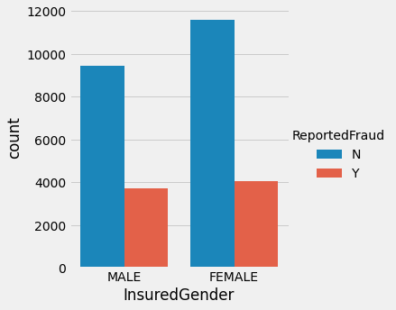

```python
#insured gender vs reported fraud
sns.catplot(data=master,x='InsuredGender',hue='ReportedFraud',kind='count')
```

```python
#insuredgender vs ReportedFraud
cross_tab('PoliceReport','ReportedFraud')
```

| ReportedFraud PoliceReport | N | Y |
| --- | --- | --- |
| NO | 7230 | 2668 |
| YES | 6721 | 2412 |
| missing | 7100 | 2705 |

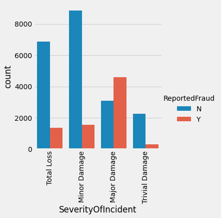

```python
#sevarity of incident vs Reportedfraud
sns.catplot(data=master,x='SeverityOfIncident',hue='ReportedFraud',kind='count')
plt.xticks(rotation = 90)
```

```python
#PropertyDamage vs ReportedFraud
cross_tab('PropertyDamage','ReportedFraud')
```

[output not shown]

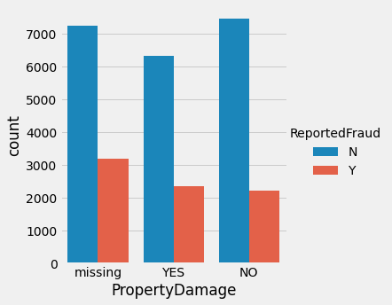

```python
sns.catplot(data=master,x='PropertyDamage',hue='ReportedFraud',kind='count')
```

```python
#InsurancePolicyState v/s ReportedFraud
cross_tab('InsurancePolicyState','ReportedFraud')
```

| ReportedFraud InsurancePolicyState | N | Y |
| --- | --- | --- |
| State1 | 7320 | 2396 |
| State2 | 6470 | 2504 |
| State3 | 7261 | 2885 |

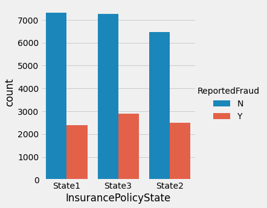

```python
#insurence policy state vs reported fraud
sns.catplot(data=master,x='InsurancePolicyState',hue='ReportedFraud',kind='count')
```

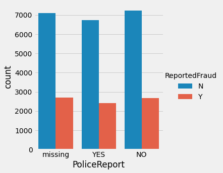

```python
sns.catplot(data=master,x='PoliceReport',hue='ReportedFraud',kind='count')
```

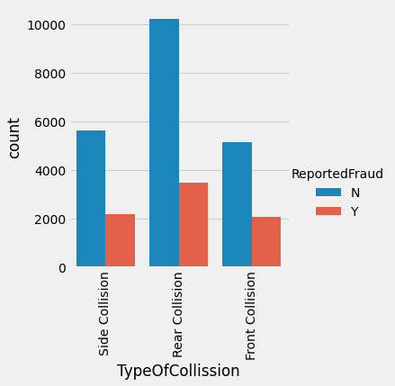

```python
sns.catplot(data=master,x='TypeOfCollission',hue='ReportedFraud',kind='count')
plt.xticks(rotation = 90)
```

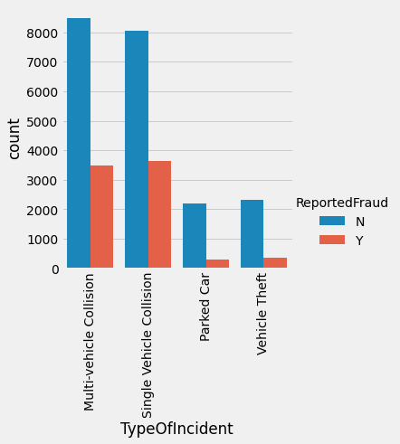

```python
#incidenttype vs ReportedFraud
sns.catplot(data=master,x='TypeOfIncident',hue='ReportedFraud',kind='count')
plt.xticks(rotation = 90)
```

```python
#insured education level v/s ReportedFraud
cross_tab('InsuredEducationLevel','ReportedFraud')
```

| ReportedFraud InsuredEducationLevel | N | Y |
| --- | --- | --- |
| Associate | 3071 | 1054 |
| College | 2439 | 1023 |
| High School | 3391 | 1192 |
| JD | 3572 | 1236 |
| MD | 3007 | 1154 |
| Masters | 3087 | 1054 |
| PhD | 2484 | 1072 |

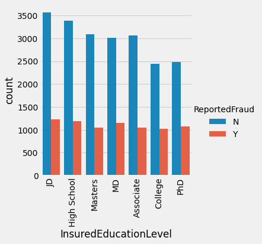

```python
sns.catplot(data=master,x='InsuredEducationLevel',hue='ReportedFraud',kind='count')
plt.xticks(rotation = 90)
```

```python
#insured relationship v/s ReportedFraud
cross_tab('InsuredRelationship','ReportedFraud')
```

| ReportedFraud InsuredRelationship | N | Y |
| --- | --- | --- |
| husband | 3840 | 1162 |
| not-in-family | 3808 | 1414 |
| other-relative | 3523 | 1630 |
| own-child | 4047 | 1195 |
| unmarried | 2754 | 1239 |
| wife | 3079 | 1145 |

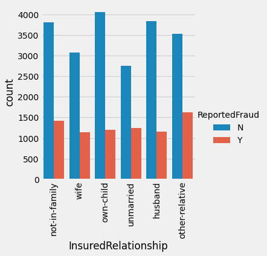

```python
sns.catplot(data=master,x='InsuredRelationship',hue='ReportedFraud',kind='count')
plt.xticks(rotation = 90)
```

```python
#authorities contacted v/s fraud reported

cross_tab('AuthoritiesContacted','ReportedFraud')
```

| ReportedFraud AuthoritiesContacted | N | Y |
| --- | --- | --- |
| Ambulance | 3971 | 1761 |
| Fire | 4602 | 1916 |
| None | 2426 | 266 |
| Other | 3764 | 1806 |
| Police | 6288 | 2036 |

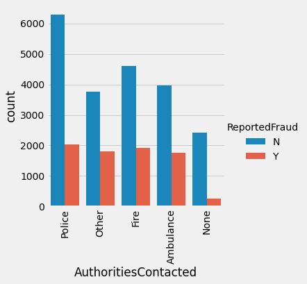

```python
#Authoritiescontacted vs reported fraud
sns.catplot(data=master,x='AuthoritiesContacted',hue='ReportedFraud',kind='count')
plt.xticks(rotation = 90)
```

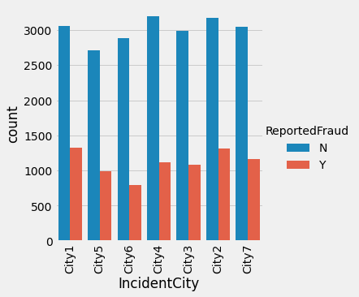

```python
#incident city vs Reported fraud
sns.catplot(data=master,x='IncidentCity',hue='ReportedFraud',kind='count')
plt.xticks(rotation = 90)
```

[figure not shown]

```python
plt.figure(figsize = (12, 5))
df_temp = master[master.ReportedFraud == 'Y']
sns.set_style('darkgrid')
sns.countplot(x = 'VehicleYOM', data = master)
plt.ylabel('No. of fraud reported')
plt.title('ReportedFraud VS VehicleYOM')
plt.xticks(rotation = 90)
```

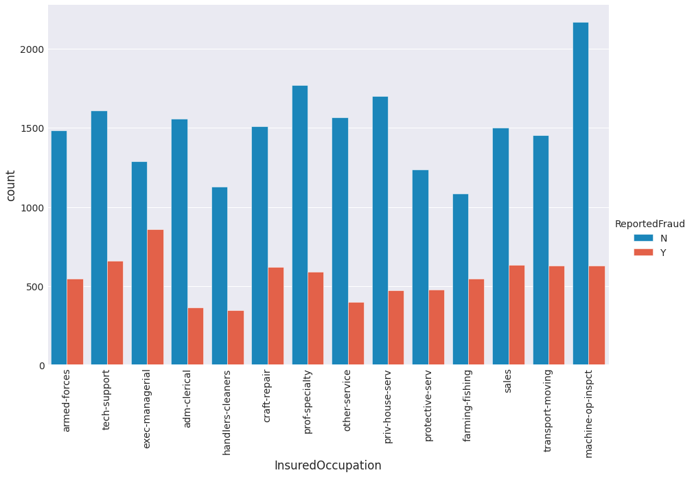

```python
sns.catplot(data=master,x='InsuredOccupation',hue='ReportedFraud',kind='count',height=8.27, aspect=12.7/8.27)
plt.xticks(rotation = 90)
```

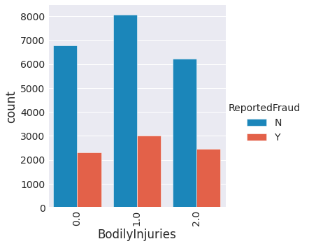

```python
sns.catplot(data=master,x='BodilyInjuries',hue='ReportedFraud',kind='count')
plt.xticks(rotation = 90)
```

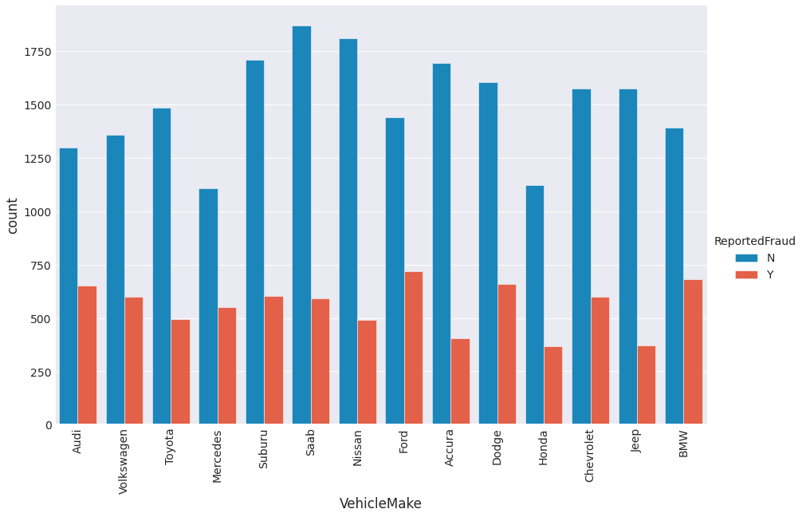

```python
sns.catplot(data=master,x='VehicleMake',hue='ReportedFraud',kind='count',height=8.27, aspect=12.7/8.27)
plt.xticks(rotation = 90)
```

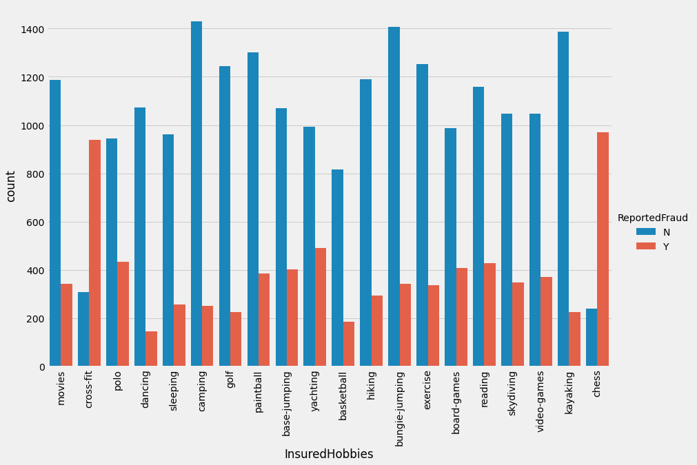

```python
#insuredd hobiees vs reported as fraud
sns.catplot(data=master,x='InsuredHobbies',hue='ReportedFraud',kind='count',height=8.27, aspect=12.7/8.27)
plt.xticks(rotation = 90)
```

[figure not shown]

```python
f, ax=plt.subplots(figsize=(20,18))
corr=master.corr()
sns.heatmap(corr,annot = True)
```

# catogorical to numerical

```python
master['PropertyDamage']= master['PropertyDamage'].map({'YES':1,'NO':0,'missing':2})
```

```python
master['PoliceReport']= master['PoliceReport'].map({'YES':1,'NO':0,'missing':2})
```

```python
master.select_dtypes(include='object').describe().T
```

|  | count | unique | top | freq |
| --- | --- | --- | --- | --- |
| DateOfIncident | 28836 | 72 | 2015-01-10 | 661 |
| TypeOfIncident | 28836 | 4 | Multi-vehicle Collision | 11966 |
| TypeOfCollission | 28836 | 3 | Rear Collision | 13723 |
| SeverityOfIncident | 28836 | 4 | Minor Damage | 10400 |
| AuthoritiesContacted | 28836 | 5 | Police | 8324 |
| IncidentState | 28836 | 7 | State5 | 7886 |
| IncidentCity | 28836 | 7 | City2 | 4486 |
| IncidentAddress | 28836 | 1000 | Location 1341 | 73 |
| InsuredGender | 28836 | 2 | FEMALE | 15674 |
| InsuredEducationLevel | 28836 | 7 | JD | 4808 |
| InsuredOccupation | 28836 | 14 | machine-op-inspct | 2798 |
| InsuredHobbies | 28836 | 20 | bungie-jumping | 1751 |
| DateOfPolicyCoverage | 28836 | 6779 | 1998-11-11 | 38 |
| InsurancePolicyState | 28836 | 3 | State3 | 10146 |
| Policy_CombinedSingleLimit | 28836 | 9 | 250/500 | 8260 |
| InsuredRelationship | 28836 | 6 | own-child | 5242 |
| VehicleMake | 28836 | 14 | Saab | 2465 |
| VehicleModel | 28836 | 39 | RAM | 1344 |
| ReportedFraud | 28836 | 2 | N | 21051 |

```python
master=master.drop(columns=['DateOfIncident','IncidentAddress','DateOfPolicyCoverage','InsuredZipCode'])
```

```python
#catogorical columns
categorical_columns = master.select_dtypes(include=['object']).columns
categorical_columns
```

```
Index(['TypeOfIncident', 'TypeOfCollission', 'SeverityOfIncident',
       'AuthoritiesContacted', 'IncidentState', 'IncidentCity',
       'InsuredGender', 'InsuredEducationLevel', 'InsuredOccupation',
       'InsuredHobbies', 'InsurancePolicyState', 'Policy_CombinedSingleLimit',
       'InsuredRelationship', 'VehicleMake', 'VehicleModel', 'ReportedFraud'],
      dtype='object')
```

```python
master.shape
```

```
(28836, 34)
```

```python
from sklearn.preprocessing import LabelEncoder
label= LabelEncoder()

for colum in categorical_columns:
    master[colum]= label.fit_transform(master[colum])
```

```python
master.head()
```

|  | TypeOfIncident | TypeOfCollission | SeverityOfIncident | AuthoritiesContacted | IncidentState | IncidentCity | IncidentTime | NumberOfVehicles | PropertyDamage | BodilyInjuries | Witnesses | PoliceReport | AmountOfTotalClaim | AmountOfInjuryClaim | AmountOfPropertyClaim | AmountOfVehicleDamage | InsuredAge | InsuredGender | InsuredEducationLevel | InsuredOccupation | InsuredHobbies | CapitalGains | CapitalLoss | CustomerLoyaltyPeriod | InsurancePolicyState | Policy_CombinedSingleLimit | Policy_Deductible | PolicyAnnualPremium | UmbrellaLimit | … |
| --- | --- | --- | --- | --- | --- | --- | --- | --- | --- | --- | --- | --- | --- | --- | --- | --- | --- | --- | --- | --- | --- | --- | --- | --- | --- | --- | --- | --- | --- | --- |
| 0 | 0 | 2 | 2 | 4 | 4 | 0 | 17.0 | 3.0 | 2 | 1.0 | 0 | 2 | 65501 | 13417.0 | 6071.0 | 46013.0 | 35.0 | 1 | 3 | 1 | 12 | 56700.0 | -48500.0 | 49.0 | 0 | 1 | 1000.0 | 1632.73 | 0.0 | … |
| 1 | 0 | 2 | 2 | 4 | 4 | 4 | 10.0 | 3.0 | 1 | 2.0 | 1 | 1 | 61382 | 15560.0 | 5919.0 | 39903.0 | 36.0 | 1 | 3 | 12 | 6 | 70600.0 | -48500.0 | 114.0 | 0 | 1 | 1000.0 | 1255.19 | 0.0 | … |
| 2 | 2 | 2 | 1 | 3 | 5 | 5 | 22.0 | 1.0 | 1 | 2.0 | 3 | 0 | 66755 | 11630.0 | 11630.0 | 43495.0 | 33.0 | 1 | 3 | 1 | 14 | 66400.0 | -63700.0 | 167.0 | 2 | 6 | 617.0 | 1373.38 | 0.0 | … |
| 3 | 2 | 2 | 1 | 3 | 6 | 5 | 22.0 | 1.0 | 1 | 2.0 | 3 | 0 | 66243 | 12003.0 | 12003.0 | 42237.0 | 36.0 | 1 | 3 | 1 | 14 | 47900.0 | -73400.0 | 190.0 | 1 | 6 | 722.0 | 1337.60 | 0.0 | … |
| 4 | 2 | 1 | 1 | 1 | 5 | 5 | 10.0 | 1.0 | 0 | 2.0 | 1 | 1 | 53544 | 8829.0 | 7234.0 | 37481.0 | 29.0 | 0 | 2 | 3 | 7 | 0.0 | -41500.0 | 115.0 | 1 | 1 | 500.0 | 1353.73 | 4279863.0 | … |

```python
master.dtypes
```

```
TypeOfIncident                  int64
TypeOfCollission                int64
SeverityOfIncident              int64
AuthoritiesContacted            int64
IncidentState                   int64
IncidentCity                    int64
IncidentTime                  float64
NumberOfVehicles              float64
PropertyDamage                  int64
BodilyInjuries                float64
Witnesses                       int64
PoliceReport                    int64
AmountOfTotalClaim              int64
AmountOfInjuryClaim           float64
AmountOfPropertyClaim         float64
AmountOfVehicleDamage         float64
InsuredAge                    float64
InsuredGender                   int64
InsuredEducationLevel           int64
InsuredOccupation               int64
InsuredHobbies                  int64
CapitalGains                  float64
CapitalLoss                   float64
CustomerLoyaltyPeriod         float64
InsurancePolicyState            int64
Policy_CombinedSingleLimit      int64
Policy_Deductible             float64
PolicyAnnualPremium           float64
UmbrellaLimit                 float64
InsuredRelationship             int64
VehicleMake                     int64
VehicleModel                    int64
VehicleYOM                    float64
ReportedFraud                   int64
dtype: object
```

```python
master.isnull().sum()
```

```
TypeOfIncident                0
TypeOfCollission              0
SeverityOfIncident            0
AuthoritiesContacted          0
IncidentState                 0
IncidentCity                  0
IncidentTime                  0
NumberOfVehicles              0
PropertyDamage                0
BodilyInjuries                0
Witnesses                     0
PoliceReport                  0
AmountOfTotalClaim            0
AmountOfInjuryClaim           0
AmountOfPropertyClaim         0
AmountOfVehicleDamage         0
InsuredAge                    0
InsuredGender                 0
InsuredEducationLevel         0
InsuredOccupation             0
InsuredHobbies                0
CapitalGains                  0
CapitalLoss                   0
CustomerLoyaltyPeriod         0
InsurancePolicyState          0
Policy_CombinedSingleLimit    0
Policy_Deductible             0
PolicyAnnualPremium           0
UmbrellaLimit                 0
InsuredRelationship           0
VehicleMake                   0
VehicleModel                  0
VehicleYOM                    0
ReportedFraud                 0
dtype: int64
```

```python
x=master.drop('ReportedFraud',axis=1)
y=master['ReportedFraud']
x.shape
```

```
(28836, 33)
```

# test data

```python
#read csv files for test data
df1=pd.read_csv("/content/drive/MyDrive/TestData/Test_Claim.csv")
df2=pd.read_csv("/content/drive/MyDrive/TestData/Test_Demographics.csv")
df3=pd.read_csv("/content/drive/MyDrive/TestData/Test_Policy.csv")
df4=pd.read_csv("/content/drive/MyDrive/TestData/Test.csv")
df5=pd.read_csv("/content/drive/MyDrive/TestData/Test_Vehicle_new.csv")
```

```python
#checking shape for test data
print(df1.shape)
print(df2.shape)
print(df3.shape)
print(df4.shape)
print(df5.shape)
```

```
(8912, 19)
(8912, 10)
(8912, 10)
(8912, 1)
(8912, 5)
```

```python
#merging all datasets based on "CstomerID"
sample_1=pd.merge(df1,df2)
sample_2=pd.merge(sample_1,df3)
sample_3=pd.merge(sample_2,df4)
test=pd.merge(sample_3,df5)
```

```python
test.head()
```

|  | CustomerID | DateOfIncident | TypeOfIncident | TypeOfCollission | SeverityOfIncident | AuthoritiesContacted | IncidentState | IncidentCity | IncidentAddress | IncidentTime | NumberOfVehicles | PropertyDamage | BodilyInjuries | Witnesses | PoliceReport | AmountOfTotalClaim | AmountOfInjuryClaim | AmountOfPropertyClaim | AmountOfVehicleDamage | InsuredAge | InsuredZipCode | InsuredGender | InsuredEducationLevel | InsuredOccupation | InsuredHobbies | CapitalGains | CapitalLoss | Country | InsurancePolicyNumber | … |
| --- | --- | --- | --- | --- | --- | --- | --- | --- | --- | --- | --- | --- | --- | --- | --- | --- | --- | --- | --- | --- | --- | --- | --- | --- | --- | --- | --- | --- | --- | --- |
| 0 | Cust10008 | 2015-02-05 | Multi-vehicle Collision | Front Collision | Minor Damage | Ambulance | State5 | City2 | Location 1354 | 4 | 3 | NO | 0 | 0 | ? | 68354 | 6835 | 8059 | 53460 | 27 | 471704 | FEMALE | High School | adm-clerical | base-jumping | 56400 | -57000 | India | 119129 | … |
| 1 | Cust10010 | 2015-01-13 | Single Vehicle Collision | Rear Collision | Minor Damage | Fire | State9 | City5 | Location 1383 | 16 | 1 | ? | 1 | 1 | ? | 55270 | 8113 | 5240 | 41917 | 40 | 455810 | FEMALE | MD | prof-specialty | golf | 56700 | -65600 | India | 119131 | … |
| 2 | Cust10015 | 2015-01-05 | Multi-vehicle Collision | Rear Collision | Minor Damage | Police | State5 | City2 | Location 2030 | 20 | 3 | NO | 0 | 1 | ? | 59515 | 7490 | 9110 | 42915 | 39 | 461919 | MALE | JD | other-service | movies | 30400 | 0 | India | 119136 | … |
| 3 | Cust10020 | 2015-01-03 | Vehicle Theft | ? | Trivial Damage | None | State7 | City5 | Location 1449 | 10 | 1 | ? | 2 | 1 | ? | 4941 | 494 | 866 | 3581 | 38 | 600904 | FEMALE | Masters | exec-managerial | video-games | 68500 | 0 | India | 119141 | … |
| 4 | Cust1003 | 2015-02-22 | Multi-vehicle Collision | Rear Collision | Minor Damage | Police | State5 | City2 | Location 1916 | 7 | 3 | NO | 2 | 3 | NO | 34650 | 7700 | 3850 | 23100 | 29 | 430632 | FEMALE | PhD | sales | board-games | 35100 | 0 | India | 110124 | … |

# **Test data Preprocessing**

```python
# Making a list of missing value types
missing_values = ["MISSEDDATA","NA","?","MISSINGVALUE","???",-5,"MISSINGVAL",-1,"N/A","na"]
```

```python
#we create one missing values list by using that if that comes in any place we replace it with nan
for column in test.columns:
    for missing in missing_values:
        test[column] = np.where(test[column]==missing, np.NaN, test[column])
```

```python
test.isnull().sum()
```

```
CustomerID                       0
DateOfIncident                   0
TypeOfIncident                   0
TypeOfCollission              1763
SeverityOfIncident               0
AuthoritiesContacted             0
IncidentState                    0
IncidentCity                     0
IncidentAddress                  0
IncidentTime                     7
NumberOfVehicles                 0
PropertyDamage                3199
BodilyInjuries                   0
Witnesses                       12
PoliceReport                  3014
AmountOfTotalClaim               8
AmountOfInjuryClaim              0
AmountOfPropertyClaim            0
AmountOfVehicleDamage            0
InsuredAge                       0
InsuredZipCode                   0
InsuredGender                    8
InsuredEducationLevel            0
InsuredOccupation                0
InsuredHobbies                   0
CapitalGains                     0
CapitalLoss                      0
Country                          4
InsurancePolicyNumber            0
CustomerLoyaltyPeriod            0
DateOfPolicyCoverage             0
InsurancePolicyState             0
Policy_CombinedSingleLimit       0
Policy_Deductible                0
PolicyAnnualPremium             47
UmbrellaLimit                    0
InsuredRelationship              0
VehicleID                        0
VehicleMake                      8
VehicleModel                     0
VehicleYOM                       0
dtype: int64
```

```python
test['PropertyDamage'].fillna('missing',inplace=True)
test['PoliceReport'].fillna('missing',inplace=True)
```

```python
test['PropertyDamage']
```

```
0            NO
1       missing
2            NO
3       missing
4            NO
         ...
8907        YES
8908    missing
8909        YES
8910        YES
8911    missing
Name: PropertyDamage, Length: 8912, dtype: object
```

```python
test['PoliceReport']
```

```
0       missing
1       missing
2       missing
3       missing
4            NO
         ...
8907         NO
8908        YES
8909         NO
8910        YES
8911    missing
Name: PoliceReport, Length: 8912, dtype: object
```

```python
test['PropertyDamage']= test['PropertyDamage'].map({'YES':1,'NO':0,'missing':2})
```

```python
test['PoliceReport']= test['PoliceReport'].map({'YES':1,'NO':0,'missing':2})
```

```python
##  Replace NAN values with most occured category in TypeOfCollission
Mode_Category = test["TypeOfCollission"].mode()[0]
test["TypeOfCollission"].fillna(Mode_Category,inplace=True)

##  Replace NAN values with median in IncidentTime
median=test['IncidentTime'].median()
test['IncidentTime'].fillna(median,inplace=True)

##  Replace NAN values with median  in witness
median_1=master['Witnesses'].median()
master['Witnesses'].fillna(median_1,inplace=True)

#drop huge no of missing value data
test.drop(['Country'],axis=1,inplace=True)

##  Replace NAN values with most occured category in police report
#Mode_Category_1 = test["PoliceReport"].mode()[0]
#test["PoliceReport"].fillna(Mode_Category_1,inplace=True)

###  Replace NAN values with median in AmountOfTotalClaim
median_2=test['AmountOfTotalClaim'].median()
test['AmountOfTotalClaim'].fillna(median_2,inplace=True)

##  Replace NAN values with most occured category in gender
Mode_Category_2 = test["InsuredGender"].mode()[0]
test["InsuredGender"].fillna(Mode_Category_2,inplace=True)

###  Replace NAN values with median in PolicyAnnualPremium
median_3=test['PolicyAnnualPremium'].median()
test['PolicyAnnualPremium'].fillna(median_3,inplace=True)

##  Replace NAN values with most occured category in VehicleMake
Mode_Category_3 = test["VehicleMake"].mode()[0]
test["VehicleMake"].fillna(Mode_Category_3,inplace=True)
```

```python
test['AmountOfTotalClaim'] = test['AmountOfTotalClaim'].astype('int')
```

```python
#remove some features which is not important
test=test.drop(columns=['InsurancePolicyNumber','DateOfIncident','IncidentAddress','DateOfPolicyCoverage','InsuredZipCode','VehicleID'])
```

```python
customerid=test['CustomerID']
test.drop(['CustomerID'],axis=1,inplace=True)
```

```python
#catogorical columns
categorical_columns = test.select_dtypes(include=['object']).columns
categorical_columns
```

```
Index(['TypeOfIncident', 'TypeOfCollission', 'SeverityOfIncident',
       'AuthoritiesContacted', 'IncidentState', 'IncidentCity', 'Witnesses',
       'InsuredGender', 'InsuredEducationLevel', 'InsuredOccupation',
       'InsuredHobbies', 'InsurancePolicyState', 'Policy_CombinedSingleLimit',
       'InsuredRelationship', 'VehicleMake', 'VehicleModel'],
      dtype='object')
```

```python
from sklearn.preprocessing import LabelEncoder
label = LabelEncoder()

for columns in categorical_columns:
    test[columns]= label.fit_transform(test[columns])
```

```python
test.dtypes
```

```
TypeOfIncident                  int64
TypeOfCollission                int64
SeverityOfIncident              int64
AuthoritiesContacted            int64
IncidentState                   int64
IncidentCity                    int64
IncidentTime                  float64
NumberOfVehicles              float64
PropertyDamage                  int64
BodilyInjuries                float64
Witnesses                       int64
PoliceReport                    int64
AmountOfTotalClaim              int64
AmountOfInjuryClaim           float64
AmountOfPropertyClaim         float64
AmountOfVehicleDamage         float64
InsuredAge                    float64
InsuredGender                   int64
InsuredEducationLevel           int64
InsuredOccupation               int64
InsuredHobbies                  int64
CapitalGains                  float64
CapitalLoss                   float64
CustomerLoyaltyPeriod         float64
InsurancePolicyState            int64
Policy_CombinedSingleLimit      int64
Policy_Deductible             float64
PolicyAnnualPremium           float64
UmbrellaLimit                 float64
InsuredRelationship             int64
VehicleMake                     int64
VehicleModel                    int64
VehicleYOM                    float64
dtype: object
```

```python
test.isnull().sum().any()
```

```
False
```

```python
test.shape
```

```
(8912, 33)
```

# **Scaling The Data**

```python
from sklearn.preprocessing import MinMaxScaler
mm=MinMaxScaler()
train_scaled=pd.DataFrame(mm.fit_transform(x))
```

```python
from sklearn.preprocessing import MinMaxScaler
mm=MinMaxScaler()
test_scaled=pd.DataFrame(mm.fit_transform(test))
```

## **Model Creation**

```python
x.head()
```

|  | TypeOfIncident | TypeOfCollission | SeverityOfIncident | AuthoritiesContacted | IncidentState | IncidentCity | IncidentTime | NumberOfVehicles | PropertyDamage | BodilyInjuries | Witnesses | PoliceReport | AmountOfTotalClaim | AmountOfInjuryClaim | AmountOfPropertyClaim | AmountOfVehicleDamage | InsuredAge | InsuredGender | InsuredEducationLevel | InsuredOccupation | InsuredHobbies | CapitalGains | CapitalLoss | CustomerLoyaltyPeriod | InsurancePolicyState | Policy_CombinedSingleLimit | Policy_Deductible | PolicyAnnualPremium | UmbrellaLimit | … |
| --- | --- | --- | --- | --- | --- | --- | --- | --- | --- | --- | --- | --- | --- | --- | --- | --- | --- | --- | --- | --- | --- | --- | --- | --- | --- | --- | --- | --- | --- | --- |
| 0 | 0 | 2 | 2 | 4 | 4 | 0 | 17.0 | 3.0 | 2 | 1.0 | 0 | 2 | 65501 | 13417.0 | 6071.0 | 46013.0 | 35.0 | 1 | 3 | 1 | 12 | 56700.0 | -48500.0 | 49.0 | 0 | 1 | 1000.0 | 1632.73 | 0.0 | … |
| 1 | 0 | 2 | 2 | 4 | 4 | 4 | 10.0 | 3.0 | 1 | 2.0 | 1 | 1 | 61382 | 15560.0 | 5919.0 | 39903.0 | 36.0 | 1 | 3 | 12 | 6 | 70600.0 | -48500.0 | 114.0 | 0 | 1 | 1000.0 | 1255.19 | 0.0 | … |
| 2 | 2 | 2 | 1 | 3 | 5 | 5 | 22.0 | 1.0 | 1 | 2.0 | 3 | 0 | 66755 | 11630.0 | 11630.0 | 43495.0 | 33.0 | 1 | 3 | 1 | 14 | 66400.0 | -63700.0 | 167.0 | 2 | 6 | 617.0 | 1373.38 | 0.0 | … |
| 3 | 2 | 2 | 1 | 3 | 6 | 5 | 22.0 | 1.0 | 1 | 2.0 | 3 | 0 | 66243 | 12003.0 | 12003.0 | 42237.0 | 36.0 | 1 | 3 | 1 | 14 | 47900.0 | -73400.0 | 190.0 | 1 | 6 | 722.0 | 1337.60 | 0.0 | … |
| 4 | 2 | 1 | 1 | 1 | 5 | 5 | 10.0 | 1.0 | 0 | 2.0 | 1 | 1 | 53544 | 8829.0 | 7234.0 | 37481.0 | 29.0 | 0 | 2 | 3 | 7 | 0.0 | -41500.0 | 115.0 | 1 | 1 | 500.0 | 1353.73 | 4279863.0 | … |

```python
print(x.shape)
print(test.shape)
```

```
(28836, 33)
(8912, 33)
```

```python
train_scaled.head()
```

|  | 0 | 1 | 2 | 3 | 4 | 5 | 6 | 7 | 8 | 9 | 10 | 11 | 12 | 13 | 14 | 15 | 16 | 17 | 18 | 19 | 20 | 21 | 22 | 23 | 24 | 25 | 26 | 27 | 28 | … |
| --- | --- | --- | --- | --- | --- | --- | --- | --- | --- | --- | --- | --- | --- | --- | --- | --- | --- | --- | --- | --- | --- | --- | --- | --- | --- | --- | --- | --- | --- | --- |
| 0 | 0.000000 | 1.0 | 0.666667 | 1.00 | 0.666667 | 0.000000 | 0.739130 | 0.666667 | 1.0 | 0.5 | 0.000000 | 1.0 | 0.569408 | 0.625501 | 0.256485 | 0.577765 | 0.355556 | 1.0 | 0.500000 | 0.076923 | 0.631579 | 0.564179 | 0.563456 | 0.100418 | 0.0 | 0.125 | 0.333333 | 0.742532 | 0.090909 | … |
| 1 | 0.000000 | 1.0 | 0.666667 | 1.00 | 0.666667 | 0.666667 | 0.434783 | 0.666667 | 0.5 | 1.0 | 0.333333 | 0.5 | 0.533519 | 0.725408 | 0.250063 | 0.500862 | 0.377778 | 1.0 | 0.500000 | 0.923077 | 0.315789 | 0.702488 | 0.563456 | 0.236402 | 0.0 | 0.125 | 0.333333 | 0.508226 | 0.090909 | … |
| 2 | 0.666667 | 1.0 | 0.333333 | 0.75 | 0.833333 | 0.833333 | 0.956522 | 0.000000 | 0.5 | 1.0 | 1.000000 | 0.0 | 0.580335 | 0.542191 | 0.491339 | 0.546072 | 0.311111 | 1.0 | 0.500000 | 0.076923 | 0.736842 | 0.660697 | 0.426643 | 0.347280 | 1.0 | 0.750 | 0.078000 | 0.581576 | 0.090909 | … |
| 3 | 0.666667 | 1.0 | 0.333333 | 0.75 | 1.000000 | 0.833333 | 0.956522 | 0.000000 | 0.5 | 1.0 | 1.000000 | 0.0 | 0.575873 | 0.559580 | 0.507098 | 0.530239 | 0.377778 | 1.0 | 0.500000 | 0.076923 | 0.736842 | 0.476617 | 0.339334 | 0.395397 | 0.5 | 0.750 | 0.148000 | 0.559371 | 0.090909 | … |
| 4 | 0.666667 | 0.5 | 0.333333 | 0.25 | 0.833333 | 0.833333 | 0.434783 | 0.000000 | 0.0 | 1.0 | 0.333333 | 0.5 | 0.465226 | 0.411608 | 0.305619 | 0.470378 | 0.222222 | 0.0 | 0.333333 | 0.230769 | 0.368421 | 0.000000 | 0.626463 | 0.238494 | 0.5 | 0.125 | 0.000000 | 0.569381 | 0.479988 | … |

```python
test_scaled.head()
```

|  | 0 | 1 | 2 | 3 | 4 | 5 | 6 | 7 | 8 | 9 | 10 | 11 | 12 | 13 | 14 | 15 | 16 | 17 | 18 | 19 | 20 | 21 | 22 | 23 | 24 | 25 | 26 | 27 | 28 | … |
| --- | --- | --- | --- | --- | --- | --- | --- | --- | --- | --- | --- | --- | --- | --- | --- | --- | --- | --- | --- | --- | --- | --- | --- | --- | --- | --- | --- | --- | --- | --- |
| 0 | 0.000000 | 0.0 | 0.333333 | 0.00 | 0.333333 | 0.166667 | 0.173913 | 0.666667 | 0.0 | 0.0 | 0.00 | 1.0 | 0.608216 | 0.325647 | 0.342965 | 0.687218 | 0.177778 | 0.0 | 0.333333 | 0.000000 | 0.000000 | 0.561194 | 0.486949 | 0.175732 | 0.5 | 0.750 | 1.000000 | 0.357872 | 0.083502 | … |
| 1 | 0.666667 | 0.5 | 0.333333 | 0.25 | 1.000000 | 0.666667 | 0.695652 | 0.000000 | 1.0 | 0.5 | 0.25 | 1.0 | 0.491624 | 0.386536 | 0.222998 | 0.538641 | 0.466667 | 0.0 | 0.666667 | 0.692308 | 0.473684 | 0.564179 | 0.409541 | 0.485356 | 1.0 | 0.125 | 0.000000 | 0.528581 | 0.083502 | … |
| 2 | 0.000000 | 0.5 | 0.333333 | 1.00 | 0.333333 | 0.166667 | 0.869565 | 0.666667 | 0.0 | 0.0 | 0.25 | 1.0 | 0.529451 | 0.356854 | 0.387693 | 0.551487 | 0.444444 | 1.0 | 0.500000 | 0.538462 | 0.631579 | 0.302488 | 1.000000 | 0.456067 | 0.5 | 0.625 | 0.333333 | 0.638254 | 0.200292 | … |
| 3 | 1.000000 | 0.5 | 1.000000 | 0.50 | 0.666667 | 0.666667 | 0.434783 | 0.000000 | 1.0 | 1.0 | 0.25 | 1.0 | 0.043138 | 0.023536 | 0.036854 | 0.045192 | 0.422222 | 0.0 | 0.833333 | 0.230769 | 0.947368 | 0.681592 | 1.000000 | 0.428870 | 1.0 | 1.000 | 1.000000 | 0.533949 | 0.638473 | … |
| 4 | 0.000000 | 0.5 | 0.333333 | 1.00 | 0.333333 | 0.166667 | 0.304348 | 0.666667 | 0.0 | 1.0 | 0.75 | 0.0 | 0.307877 | 0.366859 | 0.163844 | 0.296435 | 0.222222 | 0.0 | 1.000000 | 0.846154 | 0.105263 | 0.349254 | 1.000000 | 0.280335 | 1.0 | 0.125 | 1.000000 | 0.612301 | 0.555961 | … |

```python
from sklearn.tree import DecisionTreeClassifier
```

```python
dt=DecisionTreeClassifier()
```

```python
#fitting the model
dt.fit(train_scaled,y)
```

```
DecisionTreeClassifier()
```

```python
from sklearn import tree
```

```python
!pip install graphviz
```

```python
decision_tree=tree.export_graphviz(dt,out_file='tree.dot',feature_names=x.columns,max_depth=2,filled=True)
```

```python
!dot -Tpng tree.dot -o tree.png
```

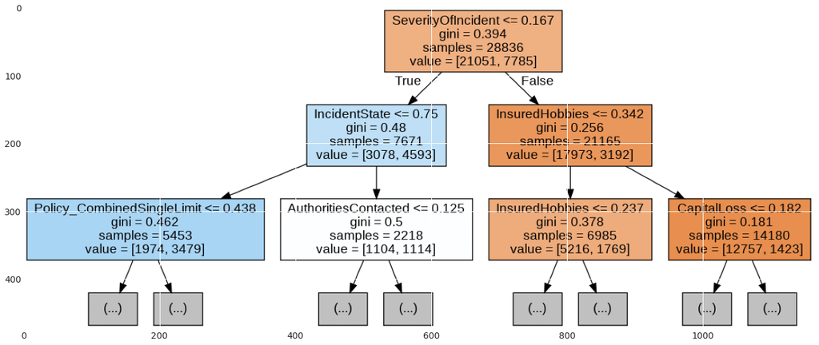

```python
image=plt.imread('tree.png')
plt.figure(figsize=(20,20))
plt.imshow(image)
```

```python
from sklearn.ensemble import RandomForestClassifier,AdaBoostClassifier,GradientBoostingClassifier
rf=RandomForestClassifier()
rf.fit(train_scaled,y)
```

```
RandomForestClassifier()
```

```python
from sklearn.ensemble import RandomForestClassifier,AdaBoostClassifier,GradientBoostingClassifier
ada=AdaBoostClassifier()
ada.fit(train_scaled,y)
```

```
AdaBoostClassifier()
```

```python
from sklearn.ensemble import RandomForestClassifier,AdaBoostClassifier,GradientBoostingClassifier
gb=GradientBoostingClassifier()
gb.fit(train_scaled,y)
```

```
GradientBoostingClassifier()
```

```python
y_pred=rf.predict(test_scaled)
y1_pred=ada.predict(test_scaled)
y2_pred=gb.predict(test_scaled)
```

```python
#model 1 randomforest classifier
y_pred
```

```
array([0, 0, 0, ..., 0, 0, 0])
```

```python
#model 2 AdaboostBoosclassifier
y1_pred
```

```
array([0, 0, 0, ..., 0, 0, 0])
```

```python
#model 3 GradientBoosting classifier
y2_pred
```

```
array([0, 0, 0, ..., 0, 0, 0])
```